# Activity 04 - Practice with ggplot2 (Solutions)

STS 2300

Updated: 2025-09-23

**As a reminder, activities are marked “Complete” or “Incomplete” and contribute to your overall grade. You must show an honest attempt for the required portions (i.e., this section).**

**This is a shorter activity, so there are no sections listed as Optional. Instead, this entire activity is considered Required.**

```r
# Load required packages here - change options to remove messages

library(ggplot2)
library(palmerpenguins) # You may need to install this one first
library(dplyr) # Used for filter() function later
```

1. Within the `palmerpenguins` package, there is a data frame called `penguins`. You may see this dataset used in some R textbooks or online examples. Use an R function (or functions) to learn more about the structure of this data. Then list examples of variables that are stored as categorical and as numeric.

```r
# Lots of ways to do this. Below are a few options.
head(penguins, n = 5)
```

```
## # A tibble: 5 × 8
##   species island    bill_length_mm bill_depth_mm flipper_length_mm body_mass_g
##   <fct>   <fct>              <dbl>         <dbl>             <int>       <int>
## 1 Adelie  Torgersen           39.1          18.7               181        3750
## 2 Adelie  Torgersen           39.5          17.4               186        3800
## 3 Adelie  Torgersen           40.3          18                 195        3250
## 4 Adelie  Torgersen           NA            NA                  NA          NA
## 5 Adelie  Torgersen           36.7          19.3               193        3450
## # ℹ 2 more variables: sex <fct>, year <int>
```

```r
str(penguins)
```

```
## tibble [344 × 8] (S3: tbl_df/tbl/data.frame)
##  $ species          : Factor w/ 3 levels "Adelie","Chinstrap",..: 1 1 1 1 1 1 1 1 1 1 ...
##  $ island           : Factor w/ 3 levels "Biscoe","Dream",..: 3 3 3 3 3 3 3 3 3 3 ...
##  $ bill_length_mm   : num [1:344] 39.1 39.5 40.3 NA 36.7 39.3 38.9 39.2 34.1 42 ...
##  $ bill_depth_mm    : num [1:344] 18.7 17.4 18 NA 19.3 20.6 17.8 19.6 18.1 20.2 ...
##  $ flipper_length_mm: int [1:344] 181 186 195 NA 193 190 181 195 193 190 ...
##  $ body_mass_g      : int [1:344] 3750 3800 3250 NA 3450 3650 3625 4675 3475 4250 ...
##  $ sex              : Factor w/ 2 levels "female","male": 2 1 1 NA 1 2 1 2 NA NA ...
##  $ year             : int [1:344] 2007 2007 2007 2007 2007 2007 2007 2007 2007 2007 ...
```

```r
# ?penguins # This one is commented out so it doesn't open a pop up window
summary(penguins)
```

```
##       species          island    bill_length_mm  bill_depth_mm
##  Adelie   :152   Biscoe   :168   Min.   :32.10   Min.   :13.10
##  Chinstrap: 68   Dream    :124   1st Qu.:39.23   1st Qu.:15.60
##  Gentoo   :124   Torgersen: 52   Median :44.45   Median :17.30
##                                  Mean   :43.92   Mean   :17.15
##                                  3rd Qu.:48.50   3rd Qu.:18.70
##                                  Max.   :59.60   Max.   :21.50
##                                  NA's   :2       NA's   :2
##  flipper_length_mm  body_mass_g       sex           year
##  Min.   :172.0     Min.   :2700   female:165   Min.   :2007
##  1st Qu.:190.0     1st Qu.:3550   male  :168   1st Qu.:2007
##  Median :197.0     Median :4050   NA's  : 11   Median :2008
##  Mean   :200.9     Mean   :4202                Mean   :2008
##  3rd Qu.:213.0     3rd Qu.:4750                3rd Qu.:2009
##  Max.   :231.0     Max.   :6300                Max.   :2009
##  NA's   :2         NA's   :2
```

**Categorical variable examples:** species, island, sex

**Numeric variable examples:** bill length/depth, flipper length, body mass

2. Let’s make a bar graph of the penguin species. Change the border around the bars to be white.

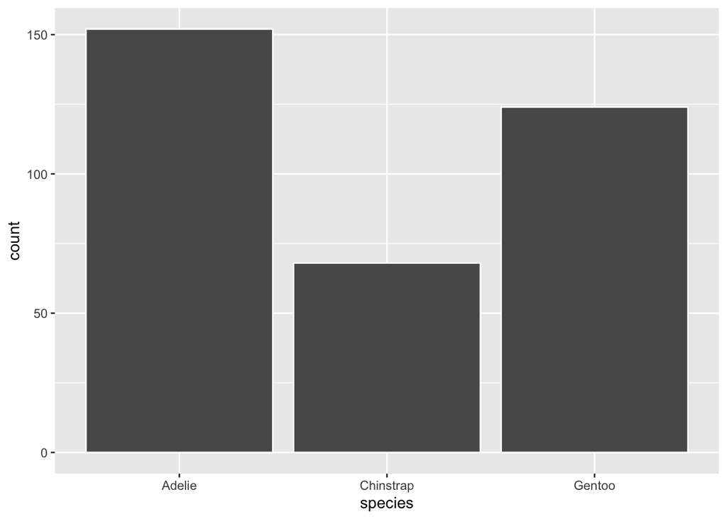

```r
ggplot(penguins) +
  geom_bar(aes(x = species),
           color = "white")
```

3. See what happens when you map the variable `sex` to the `fill` argument. (Note: Should `fill` go inside or outside of `aes()`? How do you know?)

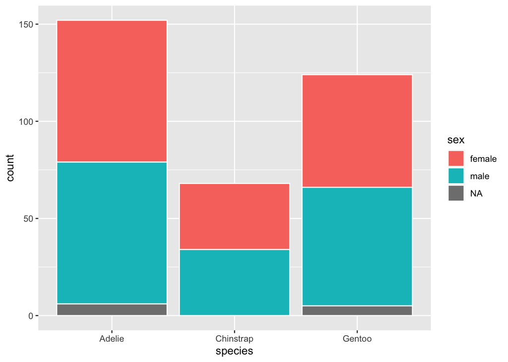

```r
ggplot(penguins) +
  geom_bar(aes(x = species,
               fill = sex),
           color = "white")
```

**What happens when we map a variable to `fill` in a bar graph?:** The bar is split into different colors depending on which category each observation falls into. For this example, the species bar (x) is split into color based on sex (fill).

4. Try adding the argument `position = "fill"` to your `geom_bar()` function. What does this do? Why might we want to view the graph this way?

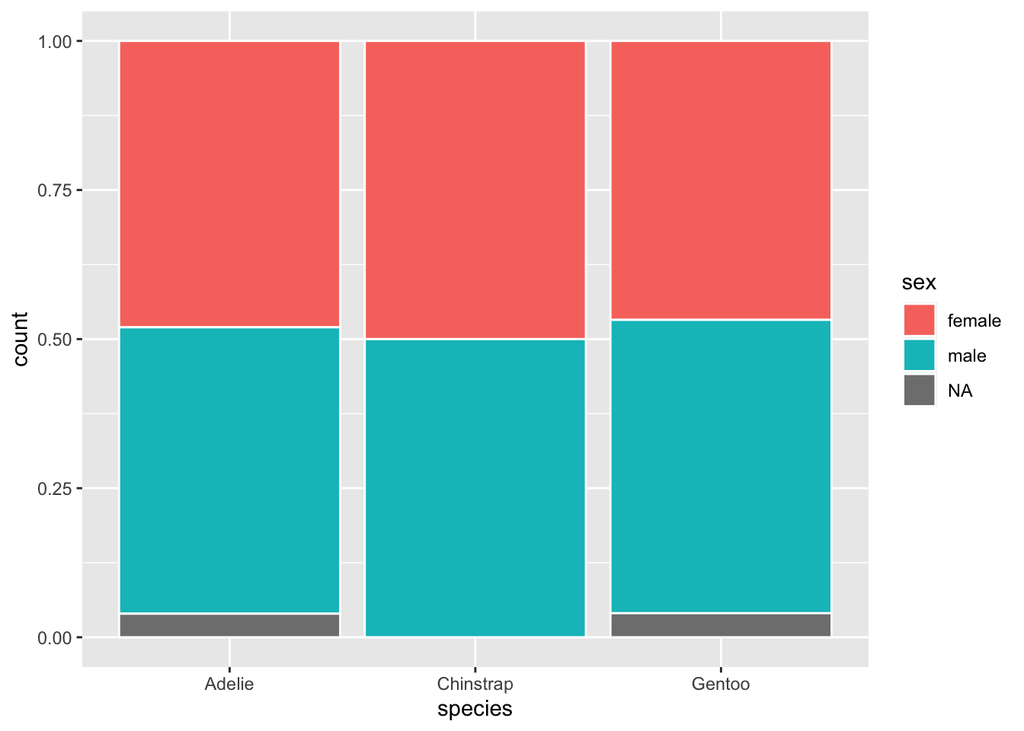

```r
ggplot(penguins) +
  geom_bar(aes(x = species,
               fill = sex),
           color = "white",
           position = "fill")
```

**What does `position = "fill"` do?:** It converts the y-axis from measuring counts to measuring proportions. Without this argument, we could see how many penguins are from each species broken down by sex. With this argument, we can see the proportion of each species that belongs to a certain sex.

**What is the benefit of viewing the graph like this?:** This makes it much easier to compare proportions across groups. I can easily see that there are similar proportions of male/female penguins among the three species.

5. Next, make a side-by-side boxplot of `bill_length_mm` by `species` where the lines around each boxplot are lightblue.

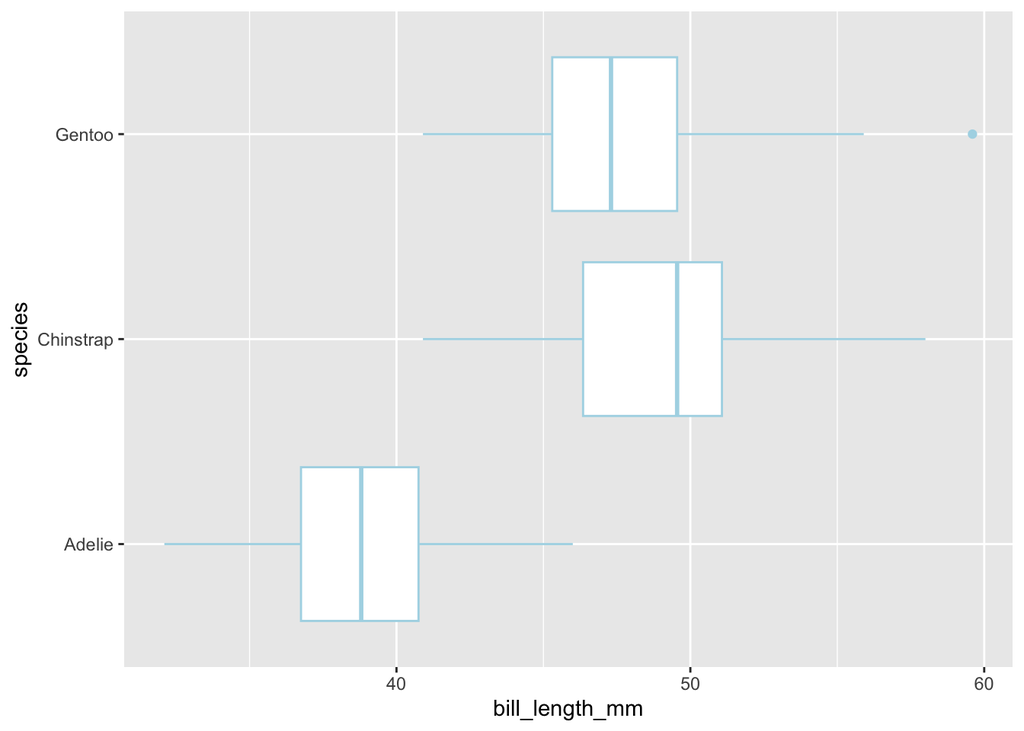

```r
ggplot(penguins) +
  geom_boxplot(aes(x = bill_length_mm,
                   y = species),
               color = "lightblue")
```

6. Add an argument that maps `sex` to `fill`. What does this do?

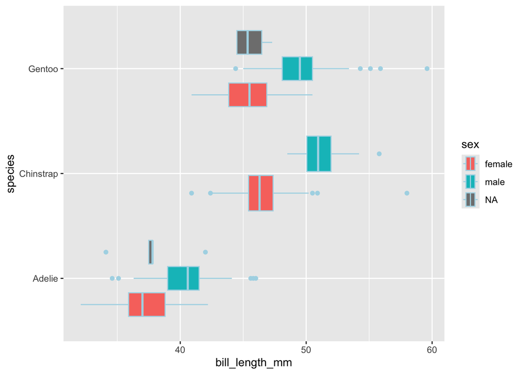

```r
ggplot(penguins) +
  geom_boxplot(aes(x = bill_length_mm,
                   y = species,
                   fill = sex),
               color = "lightblue")
```

**What does mapping a new variable to fill do?:** It creates separate boxplots for each sex that each have a different color. This is done within the grouping that we already started with (species).

7. There’s no easy way to remove the NA boxes without removing them from the data. Try replacing `penguins` in your `ggplot()` function with `filter(penguins, !is.na(sex))` and re-run your code. What is `!is.na(sex)` doing?

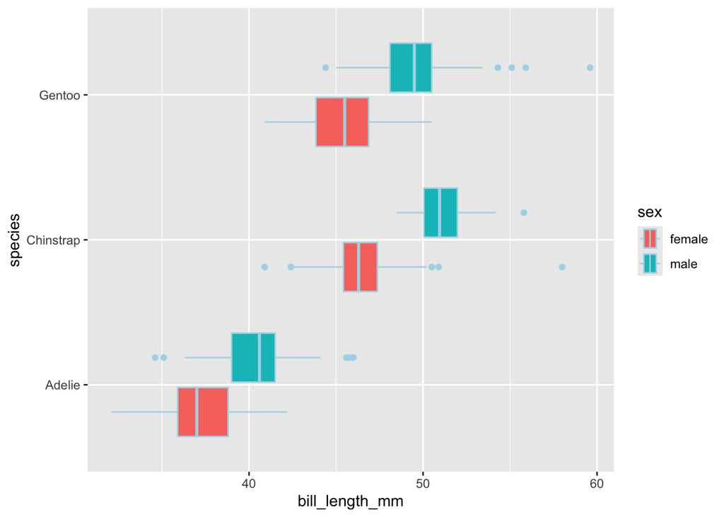

```r
# Note: You need to load dplyr for the filter() funciton to work. I added this
#   at the top of my code with my other packages.

ggplot(filter(penguins, !is.na(sex))) +
  geom_boxplot(aes(x = bill_length_mm,
                   y = species,
                   fill = sex),
               color = "lightblue")
```

**What is `!is.na(sex)` doing?:** The `is.na()` function is looking for all of the missing values within the sex variable. By adding an ! before the function, I’m now looking for values that are **not** missing.

8. One easy way to improve or customize the look of our graphs is to add a theme. We can do this by adding another function to our graphing object we are creating (like we added `geom_boxplot()` to `ggplot()`). Try adding `theme_xx()` where xx is one of the following: bw, classic, dark, minimal, void. You may want to try multiple options until you find one you like best. You can also see examples [here](https://ggplot2.tidyverse.org/reference/ggtheme.html) if you scroll down.

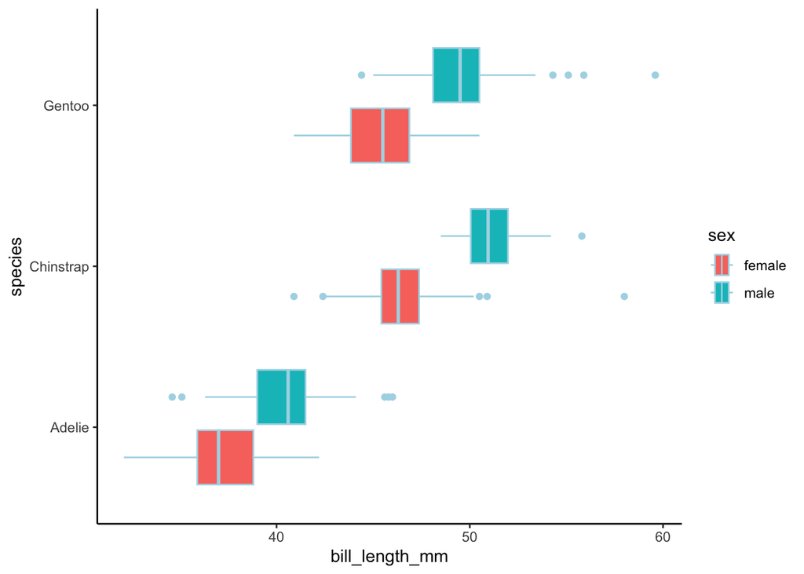

```r
library(dplyr)
ggplot(filter(penguins, !is.na(sex))) +
  geom_boxplot(aes(x = bill_length_mm,
                   y = species,
                   fill = sex),
               color = "lightblue") +
  theme_classic()
```

9. We’ve seen what happens when we map a variable to fill/color for bar graphs and box plots. Let’s see how that works with histograms. Create a histogram of `body_mass_g` and map `species` to `fill`.

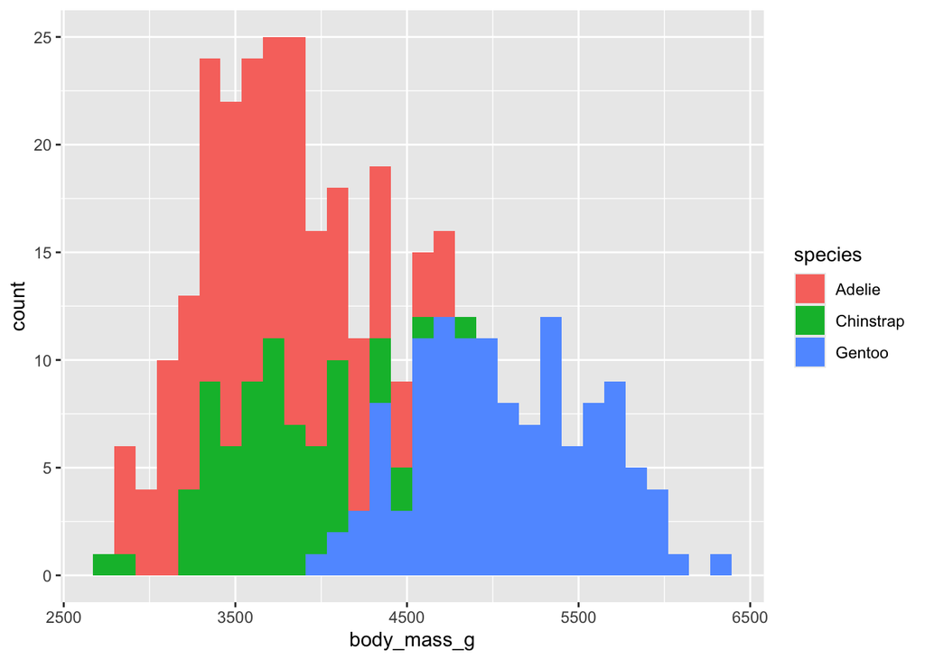

```r
ggplot(penguins) +
  geom_histogram(aes(x = body_mass_g, fill = species))
```

10. In our histogram, the three species are stacked on top of one another, which makes it hard to see how many of each there are. One option is to create separate histograms for each species. We can do this using the `facet_wrap()` function. To do this, add a layer to your graph that says `facet_wrap(vars(species))`.

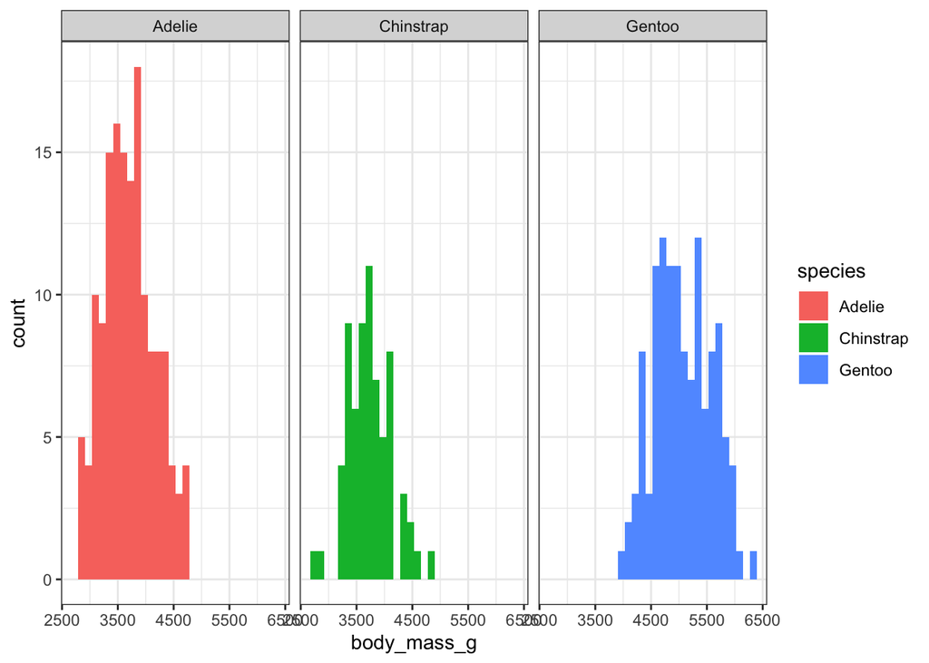

```r
ggplot(penguins) +
  geom_histogram(aes(x = body_mass_g, fill = species)) +
  facet_wrap(vars(species)) +
  theme_bw()
```

11. If we want to control how many rows or columns the graphs are put into, we can use the `nrow = __` or `ncol = __` arguments. Try using one of those arguments to stack the three histograms on top of one another. What’s an advantage to viewing the graphs this way?

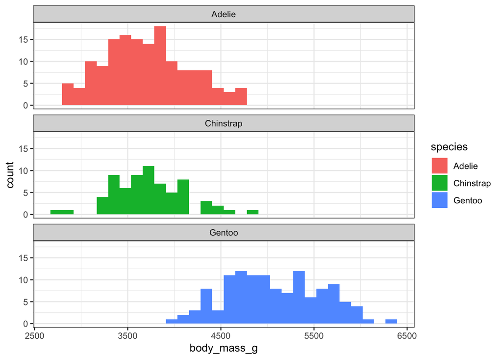

```r
ggplot(penguins) +
  geom_histogram(aes(x = body_mass_g, fill = species)) +
  facet_wrap(vars(species), ncol = 1) +
  theme_bw()
```

**Advantage to stacking the graphs:** In this graph, my histograms all use the same x-axis values which allows me to more easily compare how the body masses differ across species.

12. We can use a different function called `facet_grid()` to create a grid of graphs corresponding to our different variables. Take our histogram from question 9 and add `facet_grid(rows = vars(sex), cols = vars(species))` to it. (Note: If you want to remove NAs, go back to how we previously accomplished that).

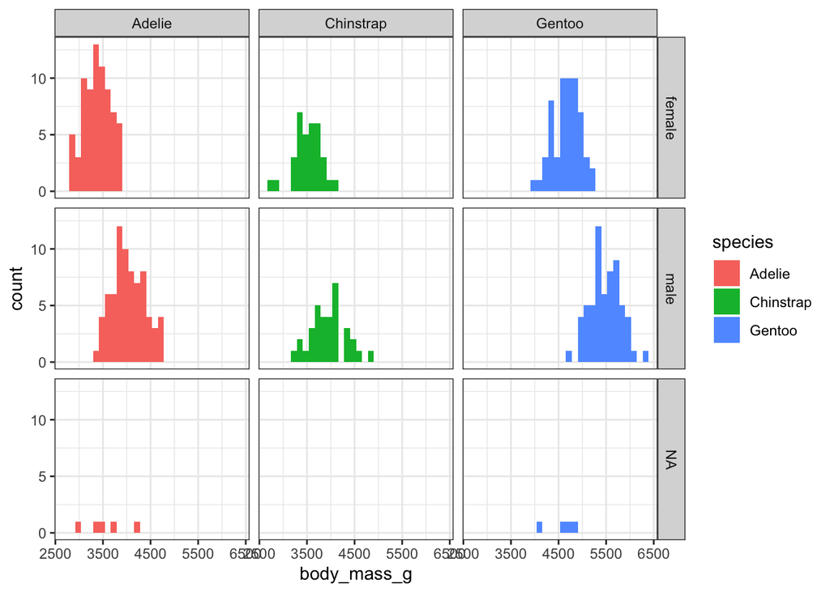

```r
ggplot(penguins) +
  geom_histogram(aes(x = body_mass_g, fill = species)) +
  facet_grid(rows = vars(sex),
             cols = vars(species)) +
  theme_bw()
```

13. Find a dataset we’ve used this semester (or another one you have) and practice applying some of these features to create a new graph. Consider adding color (as a variable or as a single color), adding a theme, facetting your graph across one or two variables, etc.

```r
# Answers will vary from person to person
```